# 645700

A1.1 Aprendizaje estadístico-automático

EXPLICACION UNO: Se importa desde la librería pandas, abreviada como pd, la funcion de read para leer de nuestro archivo de obesidad, los datos requeridos, estos se imprimen con un print y un head, este ultimo forma parte de esta librería, que su utilidad es mostrar en consola los primeros reglones de nuestro archivo a leer, en este caso se utilizan 10.

```python
import pandas as pd
datos = pd.read_csv("Obesidad.csv")
print(datos.head(10))
```

```
     Sexo  Edad  Estatura  Peso FamiliarConSobrepeso ComeMuchasCalorias  \
0  Female  21.0      1.62  64.0                  yes                 no
1  Female  21.0      1.52  56.0                  yes                 no
2    Male  23.0      1.80  77.0                  yes                 no
3    Male  27.0      1.80  87.0                   no                 no
4    Male  22.0      1.78  89.8                   no                 no
5    Male  29.0      1.62  53.0                   no                yes
6  Female  23.0      1.50  55.0                  yes                yes
7    Male  22.0      1.64  53.0                   no                 no
8    Male  24.0      1.78  64.0                  yes                yes
9    Male  22.0      1.72  68.0                  yes                yes

   ComeVegetales Fumador  ConsumoDeAgua      NivelDeObesidad
0            2.0      no            2.0        Normal_Weight
1            3.0     yes            3.0        Normal_Weight
2            2.0      no            2.0        Normal_Weight
3            3.0      no            2.0   Overweight_Level_I
4            2.0      no            2.0  Overweight_Level_II
5            2.0      no            2.0        Normal_Weight
6            3.0      no            2.0        Normal_Weight
7            2.0      no            2.0        Normal_Weight
8            3.0      no            2.0        Normal_Weight
9            2.0      no            2.0        Normal_Weight
```

EXPLICACION DOS: Otra variable posible de incorporar a la base de datos, puede ser la cantidad de actividad física semanal. Esto puede ser registrado en horas de ejercicio realizadas; considero que puede ayudar a explicarnos un balance de energía por cada persona. Este balance energético relaciona la diferencia de las calorías ingeridas y las que se gastan, bien sea por el metabolismo o a través de la actividad física. Esta actividad física es crucial para el tema pues aborda puntos como: Prevencion de aumento de peso Mejoramiento de metabolismo Reduccion de grasa corporal Etc Incluir esto permitiría desarrollar modelos predictivos asi como recomendaciones personalizadas para llevar una salud balanceada que combine el ejercicio con otros aspectos mencionados en la base de datos.

EXPLICACION TRES: En este caso consideré el nivel de obesidad como un dato fundamental para dar visibilidad a lo que estamos referenciando, pues teniendo un conteo de estos permitiría tener un control aun mas personalizado para las personas de cada categoría; este implica una variable cualitativa, porque si bien presenta valores numéricos, esta no esta registrada como un valor continuo, sino como una categoría definida la cual se basa en rangos de IMC.

EXPLICACION DE CODIGO: Aquí integramos una funcion de pandas, llamada value_counts(), la cual nos permite valorar la cantidad de personas que se encuentran en cada categoría, y lo mostramos en la pantalla con un print.

```python
print(datos.NivelDeObesidad.value_counts())
```

```
NivelDeObesidad
Obesity_Type_I         351
Obesity_Type_III       324
Obesity_Type_II        297
Overweight_Level_I     290
Overweight_Level_II    290
Normal_Weight          287
Insufficient_Weight    272
Name: count, dtype: int64
```

EXPLICACION CUATRO: Para nosotros poder implementar una grafica, debemos llamar a la función de matplotlib inline, que nos concede mostrar las graficas en la pantalla de manera correcta al trabajar con Jupyter Notebook o bien algun entorno parecido; importamos la librería de matplotlib.pyplot abreviando esta como plt, para implementar el uso de los recursos gráficos. Definimos dos variables "y" y "x" a las cuales les damos los datos de Nivel de Obesidad y Peso respectivamente; a cada uno les daremos una condición que deberá englobar solo a la población femenina en los datos que se enseñarán en la gráfica, condicionando esto a que solo se tome a las personas registradas como "Female" en los datos de Sexo. Por ultimo con nuestra funcion scatter, hacemos que cada dato se enseñe como un punto en la gráfica, mostrando su relación con los datos puestos en cada eje, dentro de scatter definí un alpha como 0.023, que solo es para darle una transparencia al punto y poder ver donde se aglomeran mas estos. La función show la usé para mostrar la gráfica en la consola.

```
Matplotlib is building the font cache; this may take a moment.
```

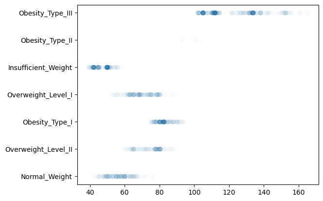

```python
%matplotlib inline
import matplotlib.pyplot as plt
y= datos.NivelDeObesidad[datos.Sexo == "Female"]
x= datos.Peso[datos.Sexo == "Female"]

plt.scatter(x, y, alpha=0.023)
plt.show()
```

Referencias:

Zelaya, D. C. P. (2025, 17 marzo). Índice de masa corporal. https://www.cun.es. https://www.cun.es/escuela-salud/indice-masa-corporal

Firma de honor: "Doy mi palabra que he realizado esta actividad con integridad académica."